# Project Python Foundations: FoodHub Data Analysis

### Context

The number of restaurants in New York is increasing day by day. Lots of students and busy professionals rely on those restaurants due to their hectic lifestyles. Online food delivery service is a great option for them. It provides them with good food from their favorite restaurants. A food aggregator company FoodHub offers access to multiple restaurants through a single smartphone app.

The app allows the restaurants to receive a direct online order from a customer. The app assigns a delivery person from the company to pick up the order after it is confirmed by the restaurant. The delivery person then uses the map to reach the restaurant and waits for the food package. Once the food package is handed over to the delivery person, he/she confirms the pick-up in the app and travels to the customer's location to deliver the food. The delivery person confirms the drop-off in the app after delivering the food package to the customer. The customer can rate the order in the app. The food aggregator earns money by collecting a fixed margin of the delivery order from the restaurants.

### Objective

The food aggregator company has stored the data of the different orders made by the registered customers in their online portal. They want to analyze the data to get a fair idea about the demand of different restaurants which will help them in enhancing their customer experience. Suppose you are hired as a Data Scientist in this company and the Data Science team has shared some of the key questions that need to be answered. Perform the data analysis to find answers to these questions that will help the company to improve the business.

### Data Description

The data contains the different data related to a food order. The detailed data dictionary is given below.

### Data Dictionary

- order_id: Unique ID of the order
- customer_id: ID of the customer who ordered the food
- restaurant_name: Name of the restaurant
- cuisine_type: Cuisine ordered by the customer
- cost_of_the_order: Cost of the order
- day_of_the_week: Indicates whether the order is placed on a weekday or weekend (The weekday is from Monday to Friday and the weekend is Saturday and Sunday)
- rating: Rating given by the customer out of 5
- food_preparation_time: Time (in minutes) taken by the restaurant to prepare the food. This is calculated by taking the difference between the timestamps of the restaurant's order confirmation and the delivery person's pick-up confirmation.
- delivery_time: Time (in minutes) taken by the delivery person to deliver the food package. This is calculated by taking the difference between the timestamps of the delivery person's pick-up confirmation and drop-off information

### Let us start by importing the required libraries

```python
# Installing the libraries with the specified version.
!pip install numpy==1.25.2 pandas==1.5.3 matplotlib==3.7.1 seaborn==0.13.1 -q --user --no-warn-script-location
```

**Note**: *After running the above cell, kindly restart the notebook kernel and run all cells sequentially from the start again.*

```python
# import libraries for data manipulation
import numpy as np
import pandas as pd

# import libraries for data visualization
import matplotlib.pyplot as plt
import seaborn as sns
```

### Understanding the structure of the data

```python
# uncomment and run the following lines for Google Colab
from google.colab import drive
drive.mount('/content/drive')
```

```python
# Write your code here to read the data
df = pd.read_csv("/content/drive/MyDrive/foodhub_order.csv")
```

```python
# Write your code here to view the first 5 rows
df.head()
```

|  | order_id | customer_id | restaurant_name | cuisine_type | cost_of_the_order | day_of_the_week | rating | food_preparation_time | delivery_time |
| --- | --- | --- | --- | --- | --- | --- | --- | --- | --- |
| 0 | 1477147 | 337525 | Hangawi | Korean | 30.75 | Weekend | Not given | 25 | 20 |
| 1 | 1477685 | 358141 | Blue Ribbon Sushi Izakaya | Japanese | 12.08 | Weekend | Not given | 25 | 23 |
| 2 | 1477070 | 66393 | Cafe Habana | Mexican | 12.23 | Weekday | 5 | 23 | 28 |
| 3 | 1477334 | 106968 | Blue Ribbon Fried Chicken | American | 29.20 | Weekend | 3 | 25 | 15 |
| 4 | 1478249 | 76942 | Dirty Bird to Go | American | 11.59 | Weekday | 4 | 25 | 24 |

### **Question 1:** How many rows and columns are present in the data? [0.5 mark]

```python
# Write your code here
rows, cols = df.shape
print(f"There are {rows} rows in the dataset")
print(f"There are {cols} columns in the dataset")
```

```
There are 1898 rows in the dataset
There are 9 columns in the dataset
```

#### Observations:

There are **1898 records** and **9 attributes** corresponding to each record in the dataset

### **Question 2:** What are the datatypes of the different columns in the dataset? (The info() function can be used) [0.5 mark]

```python
# Write your code here
df.info()
```

```
<class 'pandas.core.frame.DataFrame'>
RangeIndex: 1898 entries, 0 to 1897
Data columns (total 9 columns):
 #   Column                 Non-Null Count  Dtype
---  ------                 --------------  -----
 0   order_id               1898 non-null   int64
 1   customer_id            1898 non-null   int64
 2   restaurant_name        1898 non-null   object
 3   cuisine_type           1898 non-null   object
 4   cost_of_the_order      1898 non-null   float64
 5   day_of_the_week        1898 non-null   object
 6   rating                 1898 non-null   object
 7   food_preparation_time  1898 non-null   int64
 8   delivery_time          1898 non-null   int64
dtypes: float64(1), int64(4), object(4)
memory usage: 133.6+ KB
```

#### Observations:

The dataset consists of the following data types:

**Integer (int64):** order_id, customer_id, food_preparation_time, delivery_time

**Floating point (float64):** cost_of_the_order

**Object (basically strings):** restaurant_name, cuisine_type, day_of_the_week, rating

### **Question 3:** Are there any missing values in the data? If yes, treat them using an appropriate method. [1 mark]

```python
# Write your code here
df.isnull().sum()
```

|  | 0 |
| --- | --- |
| order_id | 0 |
| customer_id | 0 |
| restaurant_name | 0 |
| cuisine_type | 0 |
| cost_of_the_order | 0 |
| day_of_the_week | 0 |
| rating | 0 |
| food_preparation_time | 0 |
| delivery_time | 0 |

**dtype:** int64

```python
# Apparently there are no missing values, but the dataset might be using other placeholder for missng values
for cols in df.columns:
  print(df[cols].value_counts(dropna=False))
```

```
order_id
1478056    1
1477147    1
1477685    1
1477070    1
1477334    1
          ..
1478198    1
1477449    1
1476966    1
1478437    1
1477895    1
Name: count, Length: 1898, dtype: int64
customer_id
52832     13
47440     10
83287      9
250494     8
259341     7
          ..
143926     1
89574      1
157711     1
66393      1
358141     1
Name: count, Length: 1200, dtype: int64
restaurant_name
Shake Shack                  219
The Meatball Shop            132
Blue Ribbon Sushi            119
Blue Ribbon Fried Chicken     96
Parm                          68
                            ...
Rye House                      1
Hiroko's Place                 1
Frank Restaurant               1
Sarabeth's West                1
'wichcraft                     1
Name: count, Length: 178, dtype: int64
cuisine_type
```

[output cut: 62 more lines]

```
30    133
25    120
19     90
16     90
20     88
15     87
22     85
18     83
21     81
17     78
23     77
32     59
33     49
31     41
Name: count, dtype: int64
```

```python
# So rating column does contain some missing values i-e Not Given, lets create another column that contains the mean of ratings instead of missing values
df['processed_rating'] = df['rating'].replace("Not given", np.nan)
df['processed_rating'] = df['processed_rating'].astype(float)
df['processed_rating'] = df['processed_rating'].fillna(df['processed_rating'].mean())
```

```python
df.head()
```

|  | order_id | customer_id | restaurant_name | cuisine_type | cost_of_the_order | day_of_the_week | rating | food_preparation_time | delivery_time | processed_rating |
| --- | --- | --- | --- | --- | --- | --- | --- | --- | --- | --- |
| 0 | 1477147 | 337525 | Hangawi | Korean | 30.75 | Weekend | Not given | 25 | 20 | 4.344234 |
| 1 | 1477685 | 358141 | Blue Ribbon Sushi Izakaya | Japanese | 12.08 | Weekend | Not given | 25 | 23 | 4.344234 |
| 2 | 1477070 | 66393 | Cafe Habana | Mexican | 12.23 | Weekday | 5 | 23 | 28 | 5.000000 |
| 3 | 1477334 | 106968 | Blue Ribbon Fried Chicken | American | 29.20 | Weekend | 3 | 25 | 15 | 3.000000 |
| 4 | 1478249 | 76942 | Dirty Bird to Go | American | 11.59 | Weekday | 4 | 25 | 24 | 4.000000 |

#### Observations:

- No missing values were found using `df.isnull().sum()`.
- The `rating` column had `"Not given"` as a placeholder for missing data.
- These were replaced with `NaN`, converted to `float`, and filled with the column's mean and stored in another column called `processed_rating`.

### **Question 4:** Check the statistical summary of the data. What is the minimum, average, and maximum time it takes for food to be prepared once an order is placed? [2 marks]

```python
# Write your code here
min_time = df['food_preparation_time'].min()
mean_time = df['food_preparation_time'].mean()
max_time = df['food_preparation_time'].max()

print(f"Minimum Time: {min_time}min, Mean Tme: {mean_time:.2f}min, Maximum Time: {max_time}min")
```

```
Minimum Time: 20min, Mean Tme: 27.37min, Maximum Time: 35min
```

#### Observations:

- It takes a minimum of `20 minutes`, a maximum of `35 minutes` and an average of `27.37 minutes` to preapare the order

### **Question 5:** How many orders are not rated? [1 mark]

```python
# Write the code here

unrated_orders = df['rating'].value_counts()["Not given"]
print(f"Unrated Orders: {unrated_orders}")
print(f"Unrated Orders (%): {unrated_orders/rows * 100:.2f}%")
```

```
Unrated Orders: 736
Unrated Orders (%): 38.78%
```

#### Observations:

- We can see that 736 orers remain unrated which is 38.78% of total orders

### Exploratory Data Analysis (EDA)

### **Question 6:** Explore all the variables and provide observations on their distributions. (Generally, histograms, boxplots, countplots, etc. are used for univariate exploration.) [9 marks]

```python
# Write the code here
import matplotlib.pyplot as plt
import seaborn as sns
```

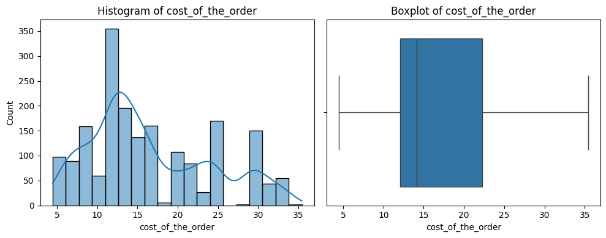

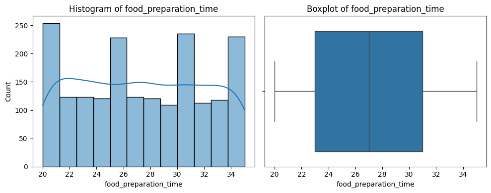

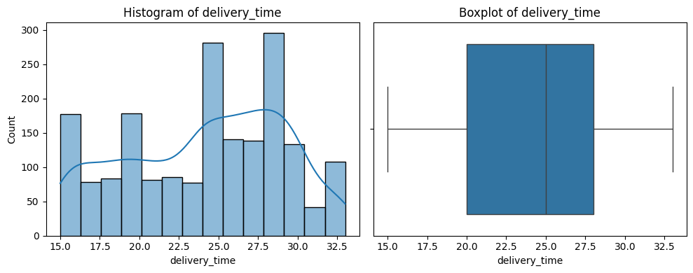

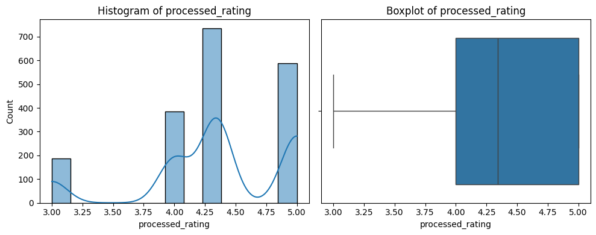

```python
num_cols = df.select_dtypes(include=['int64', 'float64']).columns # select the columns with int or float datatypes
# We will analyze such columns using histograms and boxplots

for col in num_cols:
    if "id" in col: # We don't wanna explore the id columns
      continue
    plt.figure(figsize=(10,4))

    # Histogram
    plt.subplot(1,2,1)
    sns.histplot(df[col], kde=True)
    plt.title(f'Histogram of {col}')

    # Boxplot
    plt.subplot(1,2,2)
    sns.boxplot(x=df[col])
    plt.title(f'Boxplot of {col}')

    plt.tight_layout()
    plt.show()
```

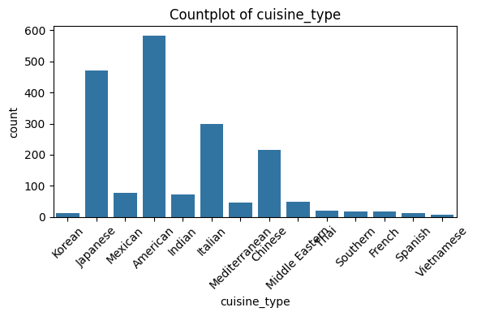

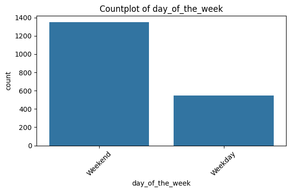

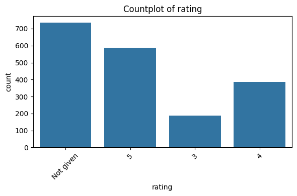

```python
cat_cols = df.select_dtypes(include='object').columns

for col in cat_cols:
  if col == "restaurant_name":
    continue
  plt.figure(figsize=(6,4))
  sns.countplot(data=df, x=col)
  plt.title(f'Countplot of {col}')
  plt.xticks(rotation=45)
  plt.tight_layout()
  plt.show()
```

#### 5. cuisine_type

- American and Japanese cuisines are the most frequently ordered.
- Other cuisines such as Vietnamese, Spanish, and French have significantly fewer entries.
- The distribution is highly imbalanced, with a strong preference for specific cuisine types.

#### 7. rating

- A large portion of ratings are marked as "Not given," indicating missing data.
- Among the provided ratings, 5-star ratings are the most common, followed by 4-star.
- Very few ratings are 3 or below, suggesting a positive bias in customer feedback.

### **Question 7**: Which are the top 5 restaurants in terms of the number of orders received? [1 mark]

```python
# Write the code here
top_restaurants = df['restaurant_name'].value_counts().head()
print(top_restaurants)
```

```
restaurant_name
Shake Shack                  219
The Meatball Shop            132
Blue Ribbon Sushi            119
Blue Ribbon Fried Chicken     96
Parm                          68
Name: count, dtype: int64
```

#### Observations:

The top 5 restaurants in terms of number of orders received are:

- Shake Shack (219 orders)
- The Meatball Shop (132 orders)
- Blue Ribbon Sushi (119 orders)
- Blue Ribbon Fried Chicken (96 orders)
- Parm (68 orders)

### **Question 8**: Which is the most popular cuisine on weekends? [1 mark]

```python
# Write the code here
weekend_orders = df[df['day_of_the_week']== "Weekend"]
popular = weekend_orders['cuisine_type'].value_counts().idxmax()
orders = weekend_orders['cuisine_type'].value_counts().max()
print(f"Most popular cuisine one weekends is {popular} with {orders} orders")
```

```
Most popular cuisine one weekends is American with 415 orders
```

#### Observations:

- The most popular cuisine during weekends is **American**, with 415 orders on weekend

### **Question 9**: What percentage of the orders cost more than 20 dollars? [2 marks]

```python
# Write the code here
total_orders = len(df)
orders_above_20 = df[df['cost_of_the_order'] > 20].shape[0]
percentage = (orders_above_20 / total_orders) * 100
print(f"{percentage:.2f}% of orders cost more than $20.")
```

```
29.24% of orders cost more than $20.
```

#### Observations:

- **29.24%** of orders cost more than $20.

### **Question 10**: What is the mean order delivery time? [1 mark]

```python
# Write the code here
mean_time = df['delivery_time'].mean()
print(f"Mean delivery time: {mean_time:.2f} mins")
```

```
Mean delivery time: 24.16 mins
```

#### Observations:

- Mean order delivery time is about 24.16 minutes

### **Question 11:** The company has decided to give 20% discount vouchers to the top 3 most frequent customers. Find the IDs of these customers and the number of orders they placed. [1 mark]

```python
# Write the code here
top_customers = df['customer_id'].value_counts().head(3)
top_customers
```

| customer_id | count |
| --- | --- |
| 52832 | 13 |
| 47440 | 10 |
| 83287 | 9 |

**dtype:** int64

#### Observations:

The 3 most frequent customers are customer # 52832, 47440 and 83287 with 13, 10 and 9 orders respectively

### **Question 12**: Perform a multivariate analysis to explore relationships between the important variables in the dataset. (It is a good idea to explore relations between numerical variables as well as relations between numerical and categorical variables) [10 marks]

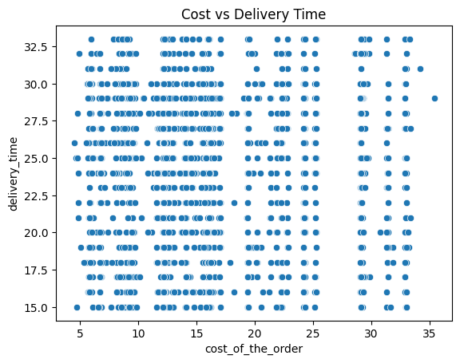

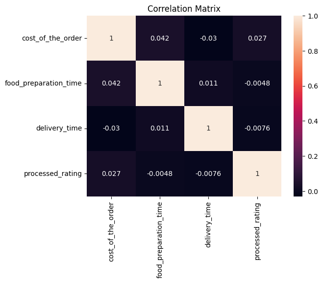

```python
# Write the code here
sns.scatterplot(x='cost_of_the_order', y='delivery_time', data=df)
plt.title('Cost vs Delivery Time')
plt.show()

sns.heatmap(df[['cost_of_the_order', 'food_preparation_time', 'delivery_time', 'processed_rating']].corr(), annot=True)
plt.title('Correlation Matrix')
plt.show()
```

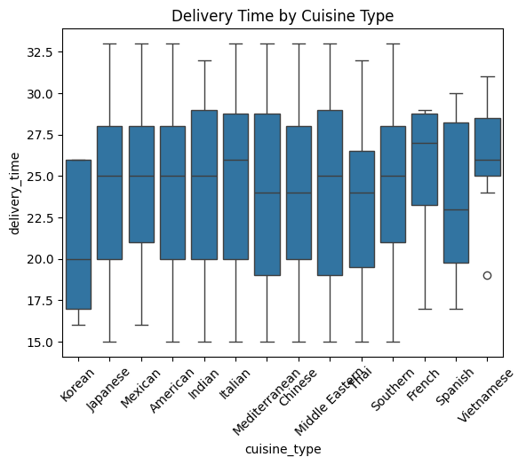

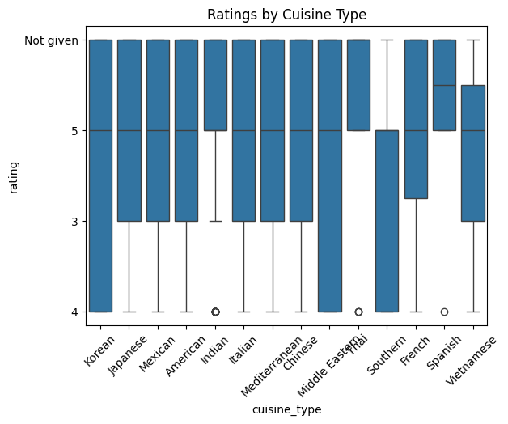

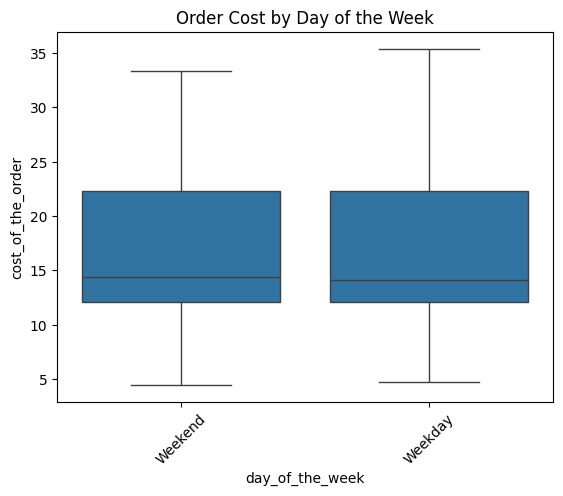

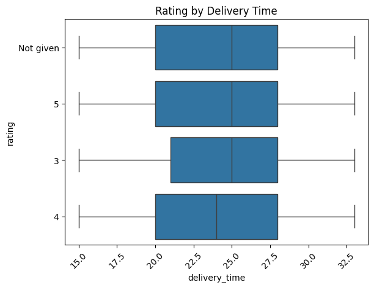

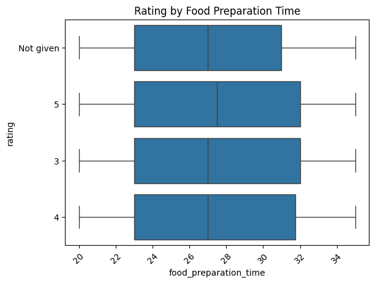

```python
sns.boxplot(x='cuisine_type', y='delivery_time', data=df)
plt.xticks(rotation=45)
plt.title('Delivery Time by Cuisine Type')
plt.show()

sns.boxplot(x='cuisine_type', y='rating', data=df)
plt.xticks(rotation=45)
plt.title('Ratings by Cuisine Type')
plt.show()

sns.boxplot(x='day_of_the_week', y='cost_of_the_order', data=df)
plt.xticks(rotation=45)
plt.title('Order Cost by Day of the Week')
plt.show()

sns.boxplot(x='delivery_time', y='rating', data=df)
plt.xticks(rotation=45)
plt.title('Rating by Delivery Time')
plt.show()

sns.boxplot(x='food_preparation_time', y='rating', data=df)
plt.xticks(rotation=45)
plt.title('Rating by Food Preparation Time')
plt.show()
```

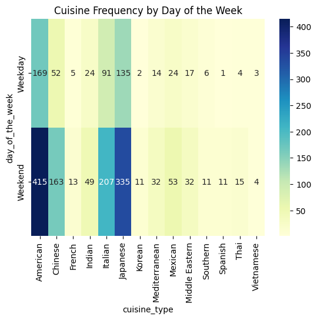

```python
crosstab = pd.crosstab(df['day_of_the_week'], df['cuisine_type'])
sns.heatmap(crosstab, annot=True, fmt='d', cmap='YlGnBu')
plt.title('Cuisine Frequency by Day of the Week')
plt.show()
```

### **Question 13:** The company wants to provide a promotional offer in the advertisement of the restaurants. The condition to get the offer is that the restaurants must have a rating count of more than 50 and the average rating should be greater than 4. Find the restaurants fulfilling the criteria to get the promotional offer. [3 marks]

```python
# Write the code here
filtered_df = df[df['rating'] != 'Not given'].copy()
filtered_df['rating'] = filtered_df['rating'].astype(float)
restaurant_rating_summary = filtered_df.groupby('restaurant_name')['rating'].agg(['count', 'mean'])
qualified_restaurants = restaurant_rating_summary[
    (restaurant_rating_summary['count'] >= 50) &
    (restaurant_rating_summary['mean'] > 4)
]

print(qualified_restaurants)
```

```
                           count      mean
restaurant_name
Blue Ribbon Fried Chicken     64  4.328125
Blue Ribbon Sushi             73  4.219178
Shake Shack                  133  4.278195
The Meatball Shop             84  4.511905
```

#### Observations:

- Only a **subset of restaurants** met both criteria: receiving **more than 50 ratings** and maintaining an **average rating above 4.0**.
- These qualifying restaurants reflect **high customer engagement** (frequent feedback) and **strong performance** in service quality.
- Most restaurants failed to meet the threshold due to either a **low number of ratings** or a **moderate average rating**.
- The selected restaurants are **ideal candidates for promotional advertisements**, as they demonstrate both **popularity** and **customer satisfaction**.
- This data-driven selection ensures that marketing efforts are **targeted toward top-performing restaurants**, likely improving campaign success.

### **Question 14:** The company charges the restaurant 25% on the orders having cost greater than 20 dollars and 15% on the orders having cost greater than 5 dollars. Find the net revenue generated by the company across all orders. [3 marks]

```python
# Write the code here
def calculate_revenue(row):
    cost = row['cost_of_the_order']
    if cost > 20:
        return cost * 0.25
    elif cost > 5:
        return cost * 0.15
    else:
        return 0

df['revenue'] = df.apply(calculate_revenue, axis=1)
net_revenue = df['revenue'].sum()
print(f"Net revenue generated by the company: ${net_revenue:.2f}")
```

```
Net revenue generated by the company: $6166.30
```

#### Observations:

- The company has a net revenue of $6166.30

### **Question 15:** The company wants to analyze the total time required to deliver the food. What percentage of orders take more than 60 minutes to get delivered from the time the order is placed? (The food has to be prepared and then delivered.) [2 marks]

```python
# Write the code here
df['total_time'] = df['food_preparation_time'] + df['delivery_time']
orders = df[df['total_time'] > 60].shape[0]
total_orders = df.shape[0]
percentage = (orders/ total_orders) * 100
print(f"{percentage:.2f}% of orders take more than 60 minutes in total.")
```

```
10.54% of orders take more than 60 minutes in total.
```

#### Observations:

- A significant portion of orders i-e 10.54% take more than 60 minutes to deliver

### **Question 16:** The company wants to analyze the delivery time of the orders on weekdays and weekends. How does the mean delivery time vary during weekdays and weekends? [2 marks]

```python
# Write the code here

mean_delivery = df.groupby('day_of_the_week')['delivery_time'].mean()
print(mean_delivery)
```

```
day_of_the_week
Weekday    28.340037
Weekend    22.470022
Name: delivery_time, dtype: float64
```

### Observations

- The **average delivery time on weekdays** is approximately **28.34 minutes**, whereas on **weekends**, it is significantly lower at **22.47 minutes**.
- This suggests that deliveries are generally **faster on weekends**.

### Conclusion and Recommendations

### **Question 17:** What are your conclusions from the analysis? What recommendations would you like to share to help improve the business? (You can use cuisine type and feedback ratings to drive your business recommendations.) [6 marks]

### Conclusions:

- **Customer Satisfaction:** The majority of ratings are 4 and above indicating High Customer Satisfaction
- **Cuisine Preferences**: **American**, **Japanese**, **Italin** and **Chineese** are the most frequently ordered, especially on weekends.-
- **Delivery Performance:** A noticeable portion of orders i-e 10.54% take more then 60 minutes to prepare and deliver, also delivery is faster on weekends then weekdays
- **High-Performing Restaurants:** Only a few restaurants meet the criteria for high-performance indicating room for improvement across many vedors

### Recommendations:

1. **Boost Feedback Collection**
   - Encourage customers to leave ratings with small incentives.
2. **Promote High-Rated, Low-Order Cuisines**
   - Use discounts or app banners to promote quality cuisines with low visibility.
3. **Improve Weekday Delivery Times**
   - Optimize delivery routes or shift staffing to reduce delays on weekdays.
4. **Reward Loyal Customers**
   - Offer exclusive vouchers or loyalty points to top repeat customers.
5. **Highlight Top Restaurants**
   - Feature high-rated restaurants more prominently in the app.
6. **Support Low-Rated Vendors**
   - Share performance reports and offer training to improve service.
7. **Upsell to Higher Order Values**
   - Recommend add-ons to push orders above $20 for better margins.